# Linear Regression Modelling Assignment

# Multivariable

To explore which covariate is the predictor for newborn’s head circumference, several multiple linear regression models are created.

## Model Exploration

### ModelWeightLength

ModelWeightLength was done using these variables

- Outcome: Head Circumference
- Covariate: Weight and Length

```r
ModelWeightLength <- lm(headc ~ weight + length, data = Data01)
summary(ModelWeightLength)
```

```
##
## Call:
## lm(formula = headc ~ weight + length, data = Data01)
##
## Residuals:
##     Min      1Q  Median      3Q     Max
## -4.4218 -0.5985  0.0380  0.7048  2.9651
##
## Coefficients:
##             Estimate Std. Error t value Pr(>|t|)
## (Intercept) 24.21402    1.14407  21.165  < 2e-16 ***
## weight       0.90147    0.10363   8.699  < 2e-16 ***
## length       0.17770    0.02591   6.858  1.9e-11 ***
## ---
## Signif. codes:  0 '***' 0.001 '**' 0.01 '*' 0.05 '.' 0.1 ' ' 1
##
## Residual standard error: 1.024 on 547 degrees of freedom
## Multiple R-squared:  0.436,  Adjusted R-squared:  0.4339
## F-statistic: 211.4 on 2 and 547 DF,  p-value: < 2.2e-16
```

```r
kable(tidy(ModelWeightLength, conf.int = T))
```

| term | estimate | std.error | statistic | p.value | conf.low | conf.high |
| --- | --- | --- | --- | --- | --- | --- |
| (Intercept) | 24.2140161 | 1.1440663 | 21.164871 | 0 | 21.9667148 | 26.4613174 |
| weight | 0.9014722 | 0.1036307 | 8.698894 | 0 | 0.6979094 | 1.1050350 |
| length | 0.1776968 | 0.0259117 | 6.857770 | 0 | 0.1267981 | 0.2285955 |

### ModelWtLtGenEduPar

ModelWtLtGenEduPar was done using these variables

- Outcome: Head Circumference
- Covariate: Weight, Length + gender + mother education + parity

```r
ModelWtLtGenEduPar <- lm(headc ~ weight + length + gender + educatio + parity, data = Data01)
summary(ModelWtLtGenEduPar)
```

```
##
## Call:
## lm(formula = headc ~ weight + length + gender + educatio + parity,
##     data = Data01)
##
## Residuals:
##     Min      1Q  Median      3Q     Max
## -4.0987 -0.6383  0.0085  0.6604  3.0413
##
## Coefficients:
##                          Estimate Std. Error t value Pr(>|t|)
## (Intercept)              24.43094    1.15667  21.122  < 2e-16 ***
## weight                    0.75217    0.10885   6.910 1.37e-11 ***
## length                    0.18700    0.02613   7.157 2.70e-12 ***
## genderFemale             -0.33734    0.09369  -3.601 0.000347 ***
## educatiosecondary        -0.07035    0.12843  -0.548 0.584085
## educatiotertiary         -0.03379    0.09930  -0.340 0.733803
## parityOne sibling         0.17507    0.10721   1.633 0.103066
## parity2 siblings          0.23295    0.12358   1.885 0.059950 .
## parity3 or more siblings  0.10108    0.15458   0.654 0.513435
## ---
## Signif. codes:  0 '***' 0.001 '**' 0.01 '*' 0.05 '.' 0.1 ' ' 1
##
## Residual standard error: 1.014 on 541 degrees of freedom
## Multiple R-squared:  0.4533, Adjusted R-squared:  0.4452
## F-statistic: 56.06 on 8 and 541 DF,  p-value: < 2.2e-16
```

```r
kable(tidy(ModelWtLtGenEduPar, conf.int = T))
```

| term | estimate | std.error | statistic | p.value | conf.low | conf.high |
| --- | --- | --- | --- | --- | --- | --- |
| (Intercept) | 24.4309365 | 1.1566692 | 21.1218000 | 0.0000000 | 22.1588233 | 26.7030498 |
| weight | 0.7521740 | 0.1088512 | 6.9101129 | 0.0000000 | 0.5383512 | 0.9659968 |
| length | 0.1870002 | 0.0261280 | 7.1570770 | 0.0000000 | 0.1356754 | 0.2383250 |
| genderFemale | -0.3373389 | 0.0936908 | -3.6005567 | 0.0003467 | -0.5213812 | -0.1532967 |
| educatiosecondary | -0.0703502 | 0.1284333 | -0.5477564 | 0.5840851 | -0.3226392 | 0.1819389 |
| educatiotertiary | -0.0337868 | 0.0993011 | -0.3402460 | 0.7338033 | -0.2288498 | 0.1612762 |
| parityOne sibling | 0.1750702 | 0.1072124 | 1.6329288 | 0.1030658 | -0.0355334 | 0.3856738 |
| parity2 siblings | 0.2329539 | 0.1235755 | 1.8851145 | 0.0599501 | -0.0097926 | 0.4757004 |
| parity3 or more siblings | 0.1010826 | 0.1545771 | 0.6539296 | 0.5134350 | -0.2025624 | 0.4047275 |

### ModelWtLtGenPar

ModelWtLtGenPar was done using these variables

- Outcome: Head Circumference
- Covariate: Weight, Length + gender + parity

```r
ModelWtLtGenPar <- lm(headc ~ weight + length + gender + parity, data = Data01)
summary(ModelWtLtGenPar)
```

```
##
## Call:
## lm(formula = headc ~ weight + length + gender + parity, data = Data01)
##
## Residuals:
##     Min      1Q  Median      3Q     Max
## -4.1464 -0.6190  0.0129  0.6439  3.0338
##
## Coefficients:
##                          Estimate Std. Error t value Pr(>|t|)
## (Intercept)              24.49275    1.14952  21.307  < 2e-16 ***
## weight                    0.75538    0.10849   6.963 9.66e-12 ***
## length                    0.18499    0.02582   7.165 2.54e-12 ***
## genderFemale             -0.33821    0.09353  -3.616 0.000327 ***
## parityOne sibling         0.18336    0.10577   1.734 0.083560 .
## parity2 siblings          0.24077    0.12220   1.970 0.049314 *
## parity3 or more siblings  0.11917    0.15008   0.794 0.427487
## ---
## Signif. codes:  0 '***' 0.001 '**' 0.01 '*' 0.05 '.' 0.1 ' ' 1
##
## Residual standard error: 1.013 on 543 degrees of freedom
## Multiple R-squared:  0.453,  Adjusted R-squared:  0.4469
## F-statistic: 74.94 on 6 and 543 DF,  p-value: < 2.2e-16
```

```r
kable(tidy(ModelWtLtGenPar, conf.int = T))
```

| term | estimate | std.error | statistic | p.value | conf.low | conf.high |
| --- | --- | --- | --- | --- | --- | --- |
| (Intercept) | 24.4927533 | 1.1495202 | 21.3069368 | 0.0000000 | 22.2347022 | 26.7508045 |
| weight | 0.7553791 | 0.1084856 | 6.9629416 | 0.0000000 | 0.5422762 | 0.9684820 |
| length | 0.1849914 | 0.0258173 | 7.1653972 | 0.0000000 | 0.1342774 | 0.2357055 |
| genderFemale | -0.3382104 | 0.0935317 | -3.6159986 | 0.0003271 | -0.5219386 | -0.1544822 |
| parityOne sibling | 0.1833599 | 0.1057694 | 1.7335817 | 0.0835600 | -0.0244074 | 0.3911273 |
| parity2 siblings | 0.2407736 | 0.1222030 | 1.9702758 | 0.0493144 | 0.0007251 | 0.4808220 |
| parity3 or more siblings | 0.1191748 | 0.1500764 | 0.7940944 | 0.4274874 | -0.1756266 | 0.4139762 |

## Model Comparison

All three model, ModelWtLt, ModelWtLtGenEduPar and ModelWtLtGenPar were compared.

```r
anova(ModelWeightLength, ModelWtLtGenEduPar)
```

|  | Res.Df | RSS | Df | Sum of Sq | F | Pr(>F) |
| --- | --- | --- | --- | --- | --- | --- |
| 1 | 547 | 574.0647 | NA | NA | NA | NA |
| 2 | 541 | 556.4440 | 6 | 17.62069 | 2.855272 | 0.009551193 |

```r
anova(ModelWeightLength, ModelWtLtGenPar)
```

|  | Res.Df | RSS | Df | Sum of Sq | F | Pr(>F) |
| --- | --- | --- | --- | --- | --- | --- |
| 1 | 547 | 574.0647 | NA | NA | NA | NA |
| 2 | 543 | 556.7623 | 4 | 17.3024 | 4.218679 | 0.002261901 |

```r
anova(ModelWtLtGenEduPar, ModelWtLtGenPar)
```

|  | Res.Df | RSS | Df | Sum of Sq | F | Pr(>F) |
| --- | --- | --- | --- | --- | --- | --- |
| 1 | 541 | 556.4440 | NA | NA | NA | NA |
| 2 | 543 | 556.7623 | -2 | -0.318287 | 0.1547265 | 0.8566873 |

For model comparison, between ModelWtLtGenEduPar and ModelWtLtGenPar, there is no significant different. Thus, ModelWtLtGenEduPar was not selected.

Thus, to choose either ModelWeightLength or ModelWtLtGenPar, adjusted R<sup>2</sup> will be use as guidance.

## Handling Confounding

There is high correlation between variable weight and length.

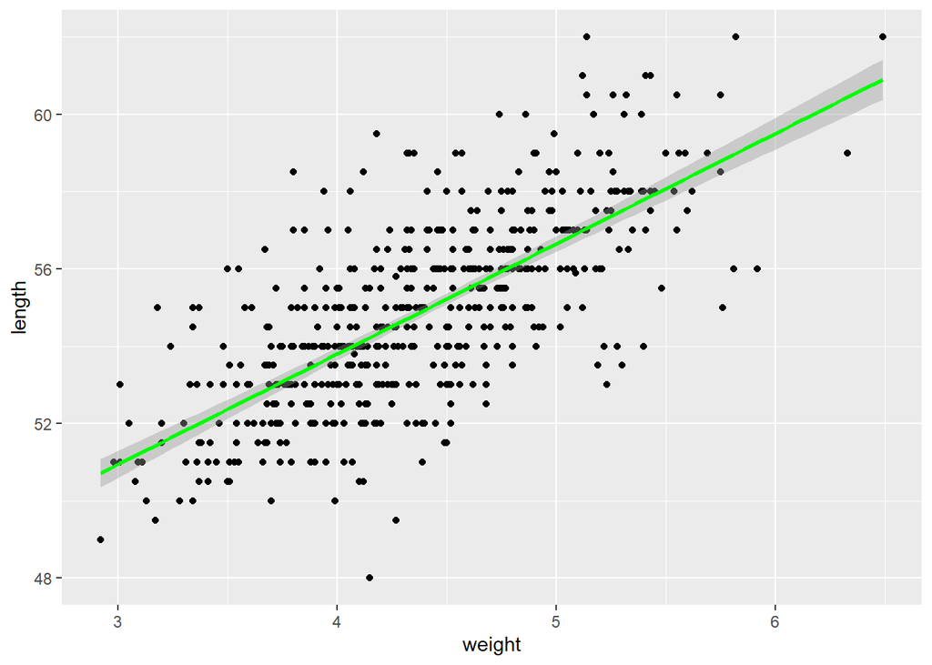

```r
ggplot(Data01, aes(weight, length)) +
  geom_point() +
  stat_smooth(method = 'lm', col = 'green')
```

Thus need to decide whether to include either one or both variables in the model.

- ModelGenParWt
- ModelGenParLt
- ModelGenParWtLt

### ModelGenParWt

ModelGenParWt was done using these variables

- outcome: head circumference
- covariate: Gender + Parity + **Weight**

```r
ModelGenParWt <- lm(headc ~ weight + gender + parity, data = Data01)
summary(ModelGenParWt)
```

```
##
## Call:
## lm(formula = headc ~ weight + gender + parity, data = Data01)
##
## Residuals:
##     Min      1Q  Median      3Q     Max
## -3.9288 -0.6261  0.0252  0.6784  3.9327
##
## Coefficients:
##                          Estimate Std. Error t value Pr(>|t|)
## (Intercept)              32.31077    0.37823  85.426   <2e-16 ***
## weight                    1.29267    0.08195  15.775   <2e-16 ***
## genderFemale             -0.32062    0.09773  -3.281   0.0011 **
## parityOne sibling         0.13451    0.11033   1.219   0.2233
## parity2 siblings          0.16550    0.12726   1.300   0.1940
## parity3 or more siblings  0.16502    0.15672   1.053   0.2928
## ---
## Signif. codes:  0 '***' 0.001 '**' 0.01 '*' 0.05 '.' 0.1 ' ' 1
##
## Residual standard error: 1.058 on 544 degrees of freedom
## Multiple R-squared:  0.4012, Adjusted R-squared:  0.3957
## F-statistic: 72.91 on 5 and 544 DF,  p-value: < 2.2e-16
```

```r
kable(tidy(ModelGenParWt))
```

| term | estimate | std.error | statistic | p.value |
| --- | --- | --- | --- | --- |
| (Intercept) | 32.3107696 | 0.3782332 | 85.425530 | 0.0000000 |
| weight | 1.2926725 | 0.0819468 | 15.774542 | 0.0000000 |
| genderFemale | -0.3206162 | 0.0977300 | -3.280631 | 0.0011021 |
| parityOne sibling | 0.1345078 | 0.1103253 | 1.219193 | 0.2232994 |
| parity2 siblings | 0.1654975 | 0.1272595 | 1.300473 | 0.1939895 |
| parity3 or more siblings | 0.1650175 | 0.1567243 | 1.052915 | 0.2928472 |

### ModelGenParLt

ModelGenParLt was done using these variables

- outcome: head circumference
- covariate: Gender + Parity + **Length**

```r
ModelGenParLt <- lm(headc ~ length + gender + parity, data = Data01)
summary(ModelGenParLt)
```

```
##
## Call:
## lm(formula = headc ~ length + gender + parity, data = Data01)
##
## Residuals:
##     Min      1Q  Median      3Q     Max
## -3.8906 -0.6971  0.0589  0.6783  2.8103
##
## Coefficients:
##                          Estimate Std. Error t value Pr(>|t|)
## (Intercept)              21.00975    1.07920  19.468  < 2e-16 ***
## length                    0.30924    0.01945  15.896  < 2e-16 ***
## genderFemale             -0.52987    0.09321  -5.685 2.14e-08 ***
## parityOne sibling         0.26748    0.10957   2.441  0.01495 *
## parity2 siblings          0.37578    0.12581   2.987  0.00295 **
## parity3 or more siblings  0.16532    0.15634   1.057  0.29077
## ---
## Signif. codes:  0 '***' 0.001 '**' 0.01 '*' 0.05 '.' 0.1 ' ' 1
##
## Residual standard error: 1.056 on 544 degrees of freedom
## Multiple R-squared:  0.4041, Adjusted R-squared:  0.3986
## F-statistic: 73.79 on 5 and 544 DF,  p-value: < 2.2e-16
```

```r
kable(tidy(ModelGenParLt))
```

| term | estimate | std.error | statistic | p.value |
| --- | --- | --- | --- | --- |
| (Intercept) | 21.0097523 | 1.0792004 | 19.467888 | 0.0000000 |
| length | 0.3092434 | 0.0194546 | 15.895606 | 0.0000000 |
| genderFemale | -0.5298706 | 0.0932092 | -5.684747 | 0.0000000 |
| parityOne sibling | 0.2674846 | 0.1095670 | 2.441288 | 0.0149527 |
| parity2 siblings | 0.3757829 | 0.1258104 | 2.986899 | 0.0029452 |
| parity3 or more siblings | 0.1653192 | 0.1563364 | 1.057458 | 0.2907718 |

### ModelGenParWtLT

ModelGenParWtLt was done using these variables

- outcome: head circumference
- covariate: Gender + Parity + **Weight** + **Length**

```r
ModelGenParWtLt <- lm(headc ~ weight + length + gender + parity, data = Data01)
summary(ModelGenParWtLt)
```

```
##
## Call:
## lm(formula = headc ~ weight + length + gender + parity, data = Data01)
##
## Residuals:
##     Min      1Q  Median      3Q     Max
## -4.1464 -0.6190  0.0129  0.6439  3.0338
##
## Coefficients:
##                          Estimate Std. Error t value Pr(>|t|)
## (Intercept)              24.49275    1.14952  21.307  < 2e-16 ***
## weight                    0.75538    0.10849   6.963 9.66e-12 ***
## length                    0.18499    0.02582   7.165 2.54e-12 ***
## genderFemale             -0.33821    0.09353  -3.616 0.000327 ***
## parityOne sibling         0.18336    0.10577   1.734 0.083560 .
## parity2 siblings          0.24077    0.12220   1.970 0.049314 *
## parity3 or more siblings  0.11917    0.15008   0.794 0.427487
## ---
## Signif. codes:  0 '***' 0.001 '**' 0.01 '*' 0.05 '.' 0.1 ' ' 1
##
## Residual standard error: 1.013 on 543 degrees of freedom
## Multiple R-squared:  0.453,  Adjusted R-squared:  0.4469
## F-statistic: 74.94 on 6 and 543 DF,  p-value: < 2.2e-16
```

```r
kable(tidy(ModelGenParWtLt))
```

| term | estimate | std.error | statistic | p.value |
| --- | --- | --- | --- | --- |
| (Intercept) | 24.4927533 | 1.1495202 | 21.3069368 | 0.0000000 |
| weight | 0.7553791 | 0.1084856 | 6.9629416 | 0.0000000 |
| length | 0.1849914 | 0.0258173 | 7.1653972 | 0.0000000 |
| genderFemale | -0.3382104 | 0.0935317 | -3.6159986 | 0.0003271 |
| parityOne sibling | 0.1833599 | 0.1057694 | 1.7335817 | 0.0835600 |
| parity2 siblings | 0.2407736 | 0.1222030 | 1.9702758 | 0.0493144 |
| parity3 or more siblings | 0.1191748 | 0.1500764 | 0.7940944 | 0.4274874 |

### Confounder Model Comparison

for Weight

```r
ModelGenParWt01 <- tidy(ModelGenParWt)
ModelGenParWtLt01 <-tidy(ModelGenParWtLt)
((ModelGenParWtLt01 [2,2] - ModelGenParWt01 [2,2])/ ModelGenParWt01 [2,2])*100
```

| estimate |
| --- |
| -41.56454 |

for Length

```r
ModelGenParLt01 <- tidy(ModelGenParLt)
((ModelGenParWtLt01 [2,2] - ModelGenParLt01 [2,2])/ ModelGenParLt01 [2,2])*100
```

| estimate |
| --- |
| 144.2669 |

Since Length have bigger difference, weight will be removed from the model. In addition to that, adjusted R<sup>2</sup> for model with length is higher than model with weight variable.

### Alternative for multicollinearity

To find multicollinearity between variables, VIF can be calculated.

```r
kable(vif(lm(headc ~ weight + length + gender + parity, data = Data01)))
```

|  | GVIF | Df | GVIF^(1/(2*Df)) |
| --- | --- | --- | --- |
| weight | 2.282350 | 1 | 1.510745 |
| length | 2.067493 | 1 | 1.437878 |
| gender | 1.173141 | 1 | 1.083116 |
| parity | 1.040684 | 3 | 1.006668 |

Based on this result, it’s seem that while weight and lenght has higher VIF value compared to other variables, but the VIF value for both variables were still less than 10.

## Interaction

Model to check for interaction is

Outcome: Head Circumference Covariate: length, gender and parity

### Interaction term - Length and Gender

ModelGenParLt_LtGen is used to examine interaction term between **length** and **gender**.

- Outcome: Head Circumference
- Covariate: length, gender, parity, length*gender

```r
ModelGenParLt_LtGen <- lm(headc ~ length + gender + parity + length:gender, data = Data01)
summary(ModelGenParLt_LtGen)
```

```
##
## Call:
## lm(formula = headc ~ length + gender + parity + length:gender,
##     data = Data01)
##
## Residuals:
##     Min      1Q  Median      3Q     Max
## -3.8363 -0.6927  0.0521  0.6727  2.7967
##
## Coefficients:
##                          Estimate Std. Error t value Pr(>|t|)
## (Intercept)              20.48514    1.43534  14.272   <2e-16 ***
## length                    0.31866    0.02583  12.338   <2e-16 ***
## genderFemale              0.66047    2.14748   0.308   0.7585
## parityOne sibling         0.27091    0.10981   2.467   0.0139 *
## parity2 siblings          0.37822    0.12597   3.003   0.0028 **
## parity3 or more siblings  0.17239    0.15695   1.098   0.2725
## length:genderFemale      -0.02174    0.03918  -0.555   0.5792
## ---
## Signif. codes:  0 '***' 0.001 '**' 0.01 '*' 0.05 '.' 0.1 ' ' 1
##
## Residual standard error: 1.057 on 543 degrees of freedom
## Multiple R-squared:  0.4045, Adjusted R-squared:  0.3979
## F-statistic: 61.46 on 6 and 543 DF,  p-value: < 2.2e-16
```

```r
kable(tidy(ModelGenParLt_LtGen))
```

| term | estimate | std.error | statistic | p.value |
| --- | --- | --- | --- | --- |
| (Intercept) | 20.4851443 | 1.4353430 | 14.2719507 | 0.0000000 |
| length | 0.3186601 | 0.0258270 | 12.3382627 | 0.0000000 |
| genderFemale | 0.6604726 | 2.1474780 | 0.3075573 | 0.7585371 |
| parityOne sibling | 0.2709094 | 0.1098104 | 2.4670650 | 0.0139301 |
| parity2 siblings | 0.3782180 | 0.1259670 | 3.0025166 | 0.0028008 |
| parity3 or more siblings | 0.1723860 | 0.1569536 | 1.0983248 | 0.2725495 |
| length:genderFemale | -0.0217392 | 0.0391823 | -0.5548217 | 0.5792451 |

The interaction model was compared with model without interaction term.

```r
anova(ModelGenParLt_LtGen, ModelGenParLt)
```

|  | Res.Df | RSS | Df | Sum of Sq | F | Pr(>F) |
| --- | --- | --- | --- | --- | --- | --- |
| 1 | 543 | 606.1300 | NA | NA | NA | NA |
| 2 | 544 | 606.4736 | -1 | -0.3436156 | 0.3078272 | 0.5792451 |

interaction term between length and gender is not significant.

### Interaction term - Length and Parity

ModelGenParLt_LtPar is used to examine interaction term between **length** and **parity**.

- Outcome: Head Circumference
- Covariate: length, gender, parity, length*parity

```r
ModelGenParLt_LtPar <- lm(headc ~ length + gender + parity + length:parity, data = Data01)
summary(ModelGenParLt_LtPar)
```

```
##
## Call:
## lm(formula = headc ~ length + gender + parity + length:parity,
##     data = Data01)
##
## Residuals:
##     Min      1Q  Median      3Q     Max
## -3.5268 -0.6998  0.0124  0.6838  2.7918
##
## Coefficients:
##                                 Estimate Std. Error t value Pr(>|t|)
## (Intercept)                     18.44617    1.81033  10.189  < 2e-16 ***
## length                           0.35600    0.03290  10.819  < 2e-16 ***
## genderFemale                    -0.51597    0.09311  -5.541  4.7e-08 ***
## parityOne sibling                4.28936    2.49964   1.716   0.0867 .
## parity2 siblings                 1.71836    2.82179   0.609   0.5428
## parity3 or more siblings         8.48474    3.68200   2.304   0.0216 *
## length:parityOne sibling        -0.07350    0.04563  -1.611   0.1078
## length:parity2 siblings         -0.02463    0.05146  -0.479   0.6323
## length:parity3 or more siblings -0.15072    0.06658  -2.264   0.0240 *
## ---
## Signif. codes:  0 '***' 0.001 '**' 0.01 '*' 0.05 '.' 0.1 ' ' 1
##
## Residual standard error: 1.053 on 541 degrees of freedom
## Multiple R-squared:  0.4109, Adjusted R-squared:  0.4022
## F-statistic: 47.18 on 8 and 541 DF,  p-value: < 2.2e-16
```

```r
kable(tidy(ModelGenParLt_LtPar))
```

| term | estimate | std.error | statistic | p.value |
| --- | --- | --- | --- | --- |
| (Intercept) | 18.4461678 | 1.8103299 | 10.1893961 | 0.0000000 |
| length | 0.3560044 | 0.0329048 | 10.8192080 | 0.0000000 |
| genderFemale | -0.5159703 | 0.0931148 | -5.5412281 | 0.0000000 |
| parityOne sibling | 4.2893630 | 2.4996420 | 1.7159909 | 0.0867362 |
| parity2 siblings | 1.7183562 | 2.8217918 | 0.6089593 | 0.5428071 |
| parity3 or more siblings | 8.4847446 | 3.6820009 | 2.3043842 | 0.0215790 |
| length:parityOne sibling | -0.0735010 | 0.0456258 | -1.6109525 | 0.1077733 |
| length:parity2 siblings | -0.0246343 | 0.0514560 | -0.4787454 | 0.6323132 |
| length:parity3 or more siblings | -0.1507180 | 0.0665791 | -2.2637423 | 0.0239852 |

The interaction model was compared with model without interaction term.

```r
anova(ModelGenParLt_LtPar, ModelGenParLt)
```

|  | Res.Df | RSS | Df | Sum of Sq | F | Pr(>F) |
| --- | --- | --- | --- | --- | --- | --- |
| 1 | 541 | 599.5244 | NA | NA | NA | NA |
| 2 | 544 | 606.4736 | -3 | -6.949252 | 2.090293 | 0.100475 |

interaction term between length and parity is not significant

### Interaction term - Gender and Parity

ModelGenParLt_GenPar is used to examine interaction term between **parity** and **gender**.

- Outcome: Head Circumference
- Covariate: length, gender, parity, gender*parity

```r
ModelGenParLt_GenPar <- lm(headc ~ length + gender + parity + gender:parity, data = Data01)
summary(ModelGenParLt_GenPar)
```

```
##
## Call:
## lm(formula = headc ~ length + gender + parity + gender:parity,
##     data = Data01)
##
## Residuals:
##     Min      1Q  Median      3Q     Max
## -4.0099 -0.6454  0.0468  0.6698  2.7718
##
## Coefficients:
##                                       Estimate Std. Error t value Pr(>|t|)
## (Intercept)                           20.90810    1.08698  19.235  < 2e-16 ***
## length                                 0.30996    0.01949  15.902  < 2e-16 ***
## genderFemale                          -0.40251    0.16055  -2.507  0.01246 *
## parityOne sibling                      0.43789    0.15322   2.858  0.00443 **
## parity2 siblings                       0.41749    0.17885   2.334  0.01995 *
## parity3 or more siblings               0.09413    0.22479   0.419  0.67557
## genderFemale:parityOne sibling        -0.34840    0.21932  -1.589  0.11275
## genderFemale:parity2 siblings         -0.08786    0.25151  -0.349  0.72699
## genderFemale:parity3 or more siblings  0.12234    0.31190   0.392  0.69503
## ---
## Signif. codes:  0 '***' 0.001 '**' 0.01 '*' 0.05 '.' 0.1 ' ' 1
##
## Residual standard error: 1.055 on 541 degrees of freedom
## Multiple R-squared:  0.4081, Adjusted R-squared:  0.3994
## F-statistic: 46.63 on 8 and 541 DF,  p-value: < 2.2e-16
```

```r
kable(tidy(ModelGenParLt_GenPar))
```

| term | estimate | std.error | statistic | p.value |
| --- | --- | --- | --- | --- |
| (Intercept) | 20.9081045 | 1.0869830 | 19.2349874 | 0.0000000 |
| length | 0.3099636 | 0.0194923 | 15.9018134 | 0.0000000 |
| genderFemale | -0.4025101 | 0.1605456 | -2.5071388 | 0.0124633 |
| parityOne sibling | 0.4378860 | 0.1532246 | 2.8578057 | 0.0044301 |
| parity2 siblings | 0.4174853 | 0.1788487 | 2.3342931 | 0.0199455 |
| parity3 or more siblings | 0.0941306 | 0.2247930 | 0.4187437 | 0.6755696 |
| genderFemale:parityOne sibling | -0.3484006 | 0.2193242 | -1.5885190 | 0.1127532 |
| genderFemale:parity2 siblings | -0.0878565 | 0.2515103 | -0.3493157 | 0.7269883 |
| genderFemale:parity3 or more siblings | 0.1223409 | 0.3119006 | 0.3922434 | 0.6950329 |

The interaction model was compared with model without interaction term.

```r
anova(ModelGenParLt_GenPar, ModelGenParLt)
```

|  | Res.Df | RSS | Df | Sum of Sq | F | Pr(>F) |
| --- | --- | --- | --- | --- | --- | --- |
| 1 | 541 | 602.3939 | NA | NA | NA | NA |
| 2 | 544 | 606.4736 | -3 | -4.079753 | 1.22132 | 0.3012112 |

interaction term between gender and parity is not significant.

## Model Assessment

Preliminary Final Model need to be assessed by checking the model assumption.

### Preliminary Final Model

Preliminary Final Model include these variables

- Outcome: Head Circumference
- Covariate: length, gender, parity

```r
ModelPrelim <- lm(headc ~ length + gender + parity, data = Data01)
summary(ModelPrelim)
```

```
##
## Call:
## lm(formula = headc ~ length + gender + parity, data = Data01)
##
## Residuals:
##     Min      1Q  Median      3Q     Max
## -3.8906 -0.6971  0.0589  0.6783  2.8103
##
## Coefficients:
##                          Estimate Std. Error t value Pr(>|t|)
## (Intercept)              21.00975    1.07920  19.468  < 2e-16 ***
## length                    0.30924    0.01945  15.896  < 2e-16 ***
## genderFemale             -0.52987    0.09321  -5.685 2.14e-08 ***
## parityOne sibling         0.26748    0.10957   2.441  0.01495 *
## parity2 siblings          0.37578    0.12581   2.987  0.00295 **
## parity3 or more siblings  0.16532    0.15634   1.057  0.29077
## ---
## Signif. codes:  0 '***' 0.001 '**' 0.01 '*' 0.05 '.' 0.1 ' ' 1
##
## Residual standard error: 1.056 on 544 degrees of freedom
## Multiple R-squared:  0.4041, Adjusted R-squared:  0.3986
## F-statistic: 73.79 on 5 and 544 DF,  p-value: < 2.2e-16
```

```r
kable(tidy(ModelPrelim))
```

| term | estimate | std.error | statistic | p.value |
| --- | --- | --- | --- | --- |
| (Intercept) | 21.0097523 | 1.0792004 | 19.467888 | 0.0000000 |
| length | 0.3092434 | 0.0194546 | 15.895606 | 0.0000000 |
| genderFemale | -0.5298706 | 0.0932092 | -5.684747 | 0.0000000 |
| parityOne sibling | 0.2674846 | 0.1095670 | 2.441288 | 0.0149527 |
| parity2 siblings | 0.3757829 | 0.1258104 | 2.986899 | 0.0029452 |
| parity3 or more siblings | 0.1653192 | 0.1563364 | 1.057458 | 0.2907718 |

### Prediction Value

Using Preliminary Final Model, prediction value was first calculated, by predicting the head circumference using the observed data from predictors variables (length, gender, parity)

```r
Pred.PrelimFinalModel <- augment(ModelPrelim)
kable(head(Pred.PrelimFinalModel))
```

| headc | length | gender | parity | .fitted | .resid | .std.resid | .hat | .sigma | .cooksd |
| --- | --- | --- | --- | --- | --- | --- | --- | --- | --- |
| 37.5 | 55.5 | Female | 3 or more siblings | 37.80821 | -0.3082077 | -0.2945439 | 0.0178592 | 1.056748 | 0.0002629 |
| 38.5 | 57.0 | Female | Singleton | 38.10675 | 0.3932465 | 0.3743960 | 0.0104126 | 1.056696 | 0.0002458 |
| 38.5 | 56.0 | Male | 2 siblings | 38.70316 | -0.2031637 | -0.1934487 | 0.0106556 | 1.056796 | 0.0000672 |
| 39.0 | 56.0 | Male | One sibling | 38.59487 | 0.4051346 | 0.3850662 | 0.0070787 | 1.056688 | 0.0001762 |
| 39.5 | 55.0 | Male | 2 siblings | 38.39392 | 1.1060797 | 1.0531862 | 0.0106511 | 1.055754 | 0.0019902 |
| 34.5 | 51.5 | Female | Singleton | 36.40592 | -1.9059150 | -1.8138686 | 0.0096644 | 1.053632 | 0.0053512 |

### Normality Test for Residual

Histogram for Residual to look for distribution shape.

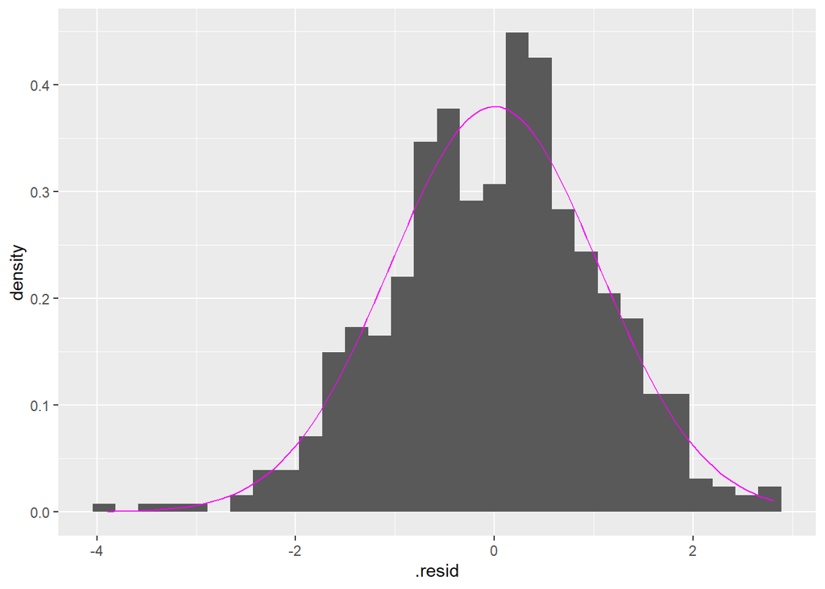

```r
ggplot(data = Pred.PrelimFinalModel, aes(x=.resid)) +
  geom_histogram(aes(y=..density..)) +
  stat_function(fun = dnorm, colour = "magenta",
                args = list(mean = mean(Pred.PrelimFinalModel$.resid),
                            sd = sd(Pred.PrelimFinalModel$.resid)))
```

Distribution of model residual look normally distributed.

Scatter plot between predicted and residual values.

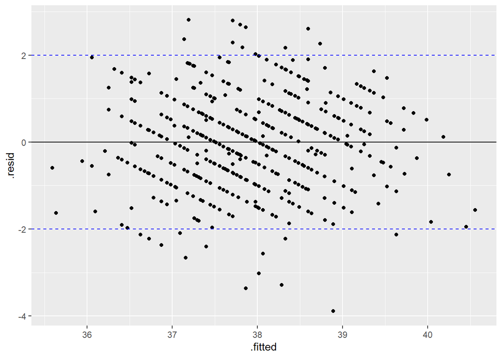

```r
ggplot(data = Pred.PrelimFinalModel, aes(x=.fitted, y=.resid)) +
  geom_point() +
  geom_hline (yintercept = 0) +
  geom_hline (yintercept = 2, linetype=2, color="blue") +
  geom_hline (yintercept = -2, linetype=2, color="blue")
```

Scatter plot seem linear and constant

Thus, these two assumption for linear regression is fulfilled

1. for each set of X<sub>i</sub> values, there is a sub-population of Y values which are normally distributed.
2. the variance of the sub-population of Y are all equal

# Outlier and Influence

Outlier and influence may affect the model. thus samples with high (or large) influence need to be removed, and the final model should be run again. Comparison between model with all samples and without influence can be done.

## Explore Influence

Measure influential in the model

1. cooks distance: value above 1 or above 4/n
2. standardized residual: values above 2 or lower than -2

```r
(2*4 +2)/550
```

```
## [1] 0.01818182
```

3. leverage above (2k +2)/n = 0.0182

## Select Influence

Sample with influence is selected using filter function

```r
influen.obs <- Pred.PrelimFinalModel %>% filter(.std.resid > 2 | .std.resid < -2 | .hat > 0.0182)
summary(influen.obs)
```

```
##      headc           length         gender                  parity
##  Min.   :34.50   Min.   :48.00   Male  :41   Singleton         : 9
##  1st Qu.:36.50   1st Qu.:53.50   Female:28   One sibling       : 8
##  Median :38.20   Median :55.00               2 siblings        :10
##  Mean   :37.93   Mean   :55.59               3 or more siblings:42
##  3rd Qu.:39.50   3rd Qu.:58.00
##  Max.   :41.20   Max.   :62.00
##     .fitted          .resid          .std.resid           .hat
##  Min.   :35.59   Min.   :-3.8906   Min.   :-3.7289   Min.   :0.007006
##  1st Qu.:37.26   1st Qu.:-1.6112   1st Qu.:-1.5410   1st Qu.:0.014743
##  Median :38.06   Median :-0.1835   Median :-0.1754   Median :0.019053
##  Mean   :38.17   Mean   :-0.2392   Mean   :-0.2288   Mean   :0.017619
##  3rd Qu.:38.89   3rd Qu.: 1.2187   3rd Qu.: 1.1666   3rd Qu.:0.021061
##  Max.   :40.56   Max.   : 2.8103   Max.   : 2.6864   Max.   :0.026367
##      .sigma         .cooksd
##  Min.   :1.043   Min.   :2.460e-06
##  1st Qu.:1.052   1st Qu.:1.088e-03
##  Median :1.055   Median :5.801e-03
##  Mean   :1.054   Mean   :6.745e-03
##  3rd Qu.:1.057   3rd Qu.:9.694e-03
##  Max.   :1.057   Max.   :5.584e-02
```

```r
kable(head(influen.obs))
```

| headc | length | gender | parity | .fitted | .resid | .std.resid | .hat | .sigma | .cooksd |
| --- | --- | --- | --- | --- | --- | --- | --- | --- | --- |
| 39.7 | 57.0 | Male | 3 or more siblings | 38.80194 | 0.8980574 | 0.8585113 | 0.0184709 | 1.056116 | 0.0023117 |
| 38.5 | 58.0 | Male | 3 or more siblings | 39.11119 | -0.6111867 | -0.5845576 | 0.0194264 | 1.056500 | 0.0011283 |
| 40.5 | 54.5 | Female | 2 siblings | 37.70943 | 2.7905720 | 2.6567023 | 0.0103362 | 1.049954 | 0.0122860 |
| 41.2 | 56.0 | Male | One sibling | 38.59487 | 2.6051354 | 2.4760897 | 0.0070787 | 1.050860 | 0.0072849 |
| 37.5 | 58.0 | Male | 3 or more siblings | 39.11119 | -1.6111867 | -1.5409880 | 0.0194264 | 1.054523 | 0.0078408 |
| 38.3 | 52.0 | Female | 3 or more siblings | 36.72586 | 1.5741433 | 1.5063883 | 0.0205063 | 1.054626 | 0.0079179 |

There are 69 samples in the original dataset which were outlier and have high leverage.

## Select Dataset without Influence Samples

Sample without influence is selected using filter function

```r
NonInfluenObs <- Pred.PrelimFinalModel %>% filter(.std.resid < 2 & .std.resid > -2 & .hat < 0.0182)
summary(NonInfluenObs)
```

```
##      headc           length         gender                   parity
##  Min.   :34.00   Min.   :49.00   Male  :234   Singleton         :171
##  1st Qu.:37.00   1st Qu.:53.00   Female:247   One sibling       :184
##  Median :38.00   Median :54.50                2 siblings        :106
##  Mean   :37.89   Mean   :54.73                3 or more siblings: 20
##  3rd Qu.:39.00   3rd Qu.:56.00
##  Max.   :41.00   Max.   :60.50
##     .fitted          .resid           .std.resid            .hat
##  Min.   :35.63   Min.   :-2.09094   Min.   :-1.99168   Min.   :0.006957
##  1st Qu.:37.29   1st Qu.:-0.62081   1st Qu.:-0.59201   1st Qu.:0.007564
##  Median :37.80   Median : 0.09589   Median : 0.09118   Median :0.008959
##  Mean   :37.86   Mean   : 0.03431   Mean   : 0.03269   Mean   :0.009947
##  3rd Qu.:38.48   3rd Qu.: 0.67262   3rd Qu.: 0.63943   3rd Qu.:0.010912
##  Max.   :39.99   Max.   : 2.02362   Max.   : 1.92390   Max.   :0.018194
##      .sigma         .cooksd
##  Min.   :1.053   Min.   :1.620e-07
##  1st Qu.:1.056   1st Qu.:1.511e-04
##  Median :1.056   Median :6.299e-04
##  Mean   :1.056   Mean   :1.291e-03
##  3rd Qu.:1.057   3rd Qu.:1.808e-03
##  Max.   :1.057   Max.   :9.365e-03
```

```r
kable(head(NonInfluenObs))
```

| headc | length | gender | parity | .fitted | .resid | .std.resid | .hat | .sigma | .cooksd |
| --- | --- | --- | --- | --- | --- | --- | --- | --- | --- |
| 37.5 | 55.5 | Female | 3 or more siblings | 37.80821 | -0.3082077 | -0.2945439 | 0.0178592 | 1.056748 | 0.0002629 |
| 38.5 | 57.0 | Female | Singleton | 38.10675 | 0.3932465 | 0.3743960 | 0.0104126 | 1.056696 | 0.0002458 |
| 38.5 | 56.0 | Male | 2 siblings | 38.70316 | -0.2031637 | -0.1934487 | 0.0106556 | 1.056796 | 0.0000672 |
| 39.0 | 56.0 | Male | One sibling | 38.59487 | 0.4051346 | 0.3850662 | 0.0070787 | 1.056688 | 0.0001762 |
| 39.5 | 55.0 | Male | 2 siblings | 38.39392 | 1.1060797 | 1.0531862 | 0.0106511 | 1.055754 | 0.0019902 |
| 34.5 | 51.5 | Female | Singleton | 36.40592 | -1.9059150 | -1.8138686 | 0.0096644 | 1.053632 | 0.0053512 |

When influence samples were removed, there were 481 samples.

the model is re-run using dataset without influence

```r
FinalModelNoInfluential <- lm(ModelPrelim, data = NonInfluenObs)
summary(FinalModelNoInfluential)
```

```
##
## Call:
## lm(formula = ModelPrelim, data = NonInfluenObs)
##
## Residuals:
##      Min       1Q   Median       3Q      Max
## -2.12254 -0.64978  0.03099  0.64903  2.05179
##
## Coefficients:
##                          Estimate Std. Error t value Pr(>|t|)
## (Intercept)              19.95790    1.06077  18.815  < 2e-16 ***
## length                    0.32905    0.01916  17.171  < 2e-16 ***
## genderFemale             -0.55294    0.08704  -6.353 4.95e-10 ***
## parityOne sibling         0.25534    0.09680   2.638  0.00862 **
## parity2 siblings          0.44252    0.11273   3.926 9.93e-05 ***
## parity3 or more siblings  0.26013    0.21813   1.193  0.23364
## ---
## Signif. codes:  0 '***' 0.001 '**' 0.01 '*' 0.05 '.' 0.1 ' ' 1
##
## Residual standard error: 0.9109 on 475 degrees of freedom
## Multiple R-squared:  0.4833, Adjusted R-squared:  0.4779
## F-statistic: 88.87 on 5 and 475 DF,  p-value: < 2.2e-16
```

```r
kable(tidy(FinalModelNoInfluential))
```

| term | estimate | std.error | statistic | p.value |
| --- | --- | --- | --- | --- |
| (Intercept) | 19.9579008 | 1.0607695 | 18.814550 | 0.0000000 |
| length | 0.3290487 | 0.0191630 | 17.171016 | 0.0000000 |
| genderFemale | -0.5529428 | 0.0870370 | -6.352961 | 0.0000000 |
| parityOne sibling | 0.2553355 | 0.0968039 | 2.637656 | 0.0086219 |
| parity2 siblings | 0.4425243 | 0.1127273 | 3.925617 | 0.0000993 |
| parity3 or more siblings | 0.2601264 | 0.2181259 | 1.192551 | 0.2336404 |

## Comparing Final Model with Final Model without Influence

### Final Model with Original Dataset (Without Influence removed)

Final Model with Original Dataset (Without Influence removed)

```r
ModelFinal <- ModelPrelim
summary(ModelFinal)
```

```
##
## Call:
## lm(formula = headc ~ length + gender + parity, data = Data01)
##
## Residuals:
##     Min      1Q  Median      3Q     Max
## -3.8906 -0.6971  0.0589  0.6783  2.8103
##
## Coefficients:
##                          Estimate Std. Error t value Pr(>|t|)
## (Intercept)              21.00975    1.07920  19.468  < 2e-16 ***
## length                    0.30924    0.01945  15.896  < 2e-16 ***
## genderFemale             -0.52987    0.09321  -5.685 2.14e-08 ***
## parityOne sibling         0.26748    0.10957   2.441  0.01495 *
## parity2 siblings          0.37578    0.12581   2.987  0.00295 **
## parity3 or more siblings  0.16532    0.15634   1.057  0.29077
## ---
## Signif. codes:  0 '***' 0.001 '**' 0.01 '*' 0.05 '.' 0.1 ' ' 1
##
## Residual standard error: 1.056 on 544 degrees of freedom
## Multiple R-squared:  0.4041, Adjusted R-squared:  0.3986
## F-statistic: 73.79 on 5 and 544 DF,  p-value: < 2.2e-16
```

```r
kable(tidy(ModelFinal, conf.int = T))
```

| term | estimate | std.error | statistic | p.value | conf.low | conf.high |
| --- | --- | --- | --- | --- | --- | --- |
| (Intercept) | 21.0097523 | 1.0792004 | 19.467888 | 0.0000000 | 18.8898419 | 23.1296627 |
| length | 0.3092434 | 0.0194546 | 15.895606 | 0.0000000 | 0.2710279 | 0.3474588 |
| genderFemale | -0.5298706 | 0.0932092 | -5.684747 | 0.0000000 | -0.7129646 | -0.3467766 |
| parityOne sibling | 0.2674846 | 0.1095670 | 2.441288 | 0.0149527 | 0.0522584 | 0.4827108 |
| parity2 siblings | 0.3757829 | 0.1258104 | 2.986899 | 0.0029452 | 0.1286492 | 0.6229166 |
| parity3 or more siblings | 0.1653192 | 0.1563364 | 1.057458 | 0.2907718 | -0.1417777 | 0.4724161 |

Residual Histogram

```r
Pred.FinalModelOriginal <- augment(ModelFinal)
kable(head(Pred.FinalModelOriginal))
```

| headc | length | gender | parity | .fitted | .resid | .std.resid | .hat | .sigma | .cooksd |
| --- | --- | --- | --- | --- | --- | --- | --- | --- | --- |
| 37.5 | 55.5 | Female | 3 or more siblings | 37.80821 | -0.3082077 | -0.2945439 | 0.0178592 | 1.056748 | 0.0002629 |
| 38.5 | 57.0 | Female | Singleton | 38.10675 | 0.3932465 | 0.3743960 | 0.0104126 | 1.056696 | 0.0002458 |
| 38.5 | 56.0 | Male | 2 siblings | 38.70316 | -0.2031637 | -0.1934487 | 0.0106556 | 1.056796 | 0.0000672 |
| 39.0 | 56.0 | Male | One sibling | 38.59487 | 0.4051346 | 0.3850662 | 0.0070787 | 1.056688 | 0.0001762 |
| 39.5 | 55.0 | Male | 2 siblings | 38.39392 | 1.1060797 | 1.0531862 | 0.0106511 | 1.055754 | 0.0019902 |
| 34.5 | 51.5 | Female | Singleton | 36.40592 | -1.9059150 | -1.8138686 | 0.0096644 | 1.053632 | 0.0053512 |

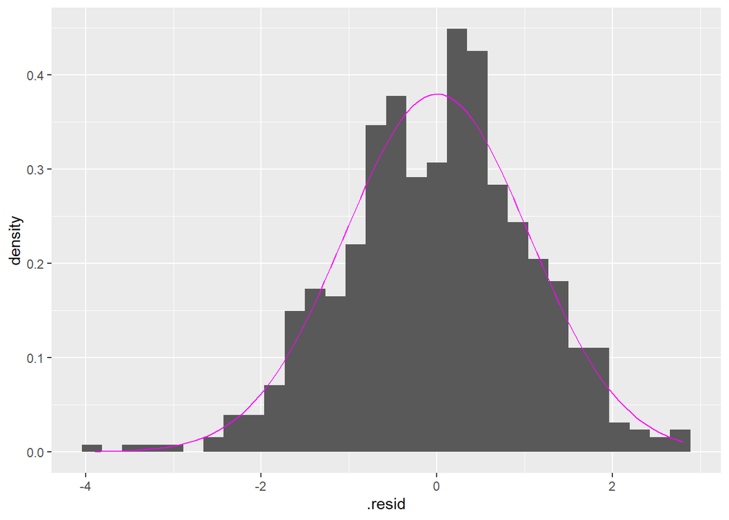

```r
ggplot(data = Pred.FinalModelOriginal, aes(x=.resid)) +
  geom_histogram(aes(y=..density..)) +
  stat_function(fun = dnorm, colour = "magenta",
                args = list(mean = mean(Pred.FinalModelOriginal$.resid),
                            sd = sd(Pred.FinalModelOriginal$.resid)))
```

Residual Histogram look normally distributed

Scatter plot between Predicted and Residual value

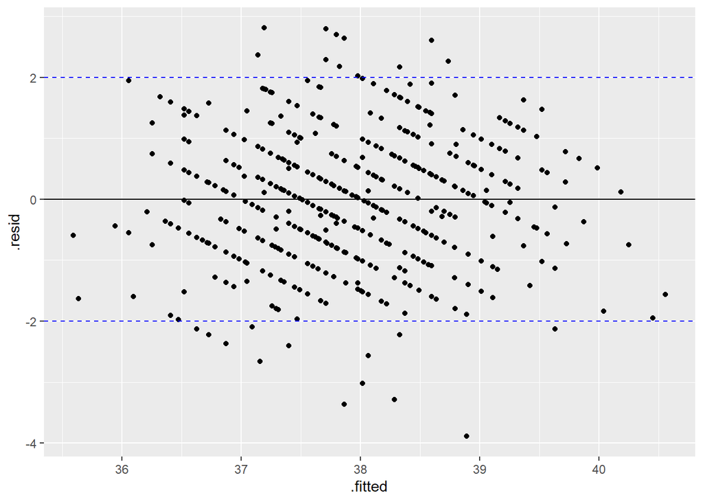

```r
ggplot(data = Pred.FinalModelOriginal, aes(x=.fitted, y=.resid)) +
  geom_point() +
  geom_hline (yintercept = 0) +
  geom_hline (yintercept = 2, linetype=2, color="blue") +
  geom_hline (yintercept = -2, linetype=2, color="blue")
```

Scatter plot seem linear and constant

Thus, these two assumption for linear regression is fulfilled

1. for each set of $X$<sub>i</sub> values, there is a sub-population of $Y$ values which are normally distributed.
2. the variance of the sub-population of $Y$ are all equal

### Final Model with Influence Removed

Final Model with Influence Removed

```r
summary(FinalModelNoInfluential)
```

```
##
## Call:
## lm(formula = ModelPrelim, data = NonInfluenObs)
##
## Residuals:
##      Min       1Q   Median       3Q      Max
## -2.12254 -0.64978  0.03099  0.64903  2.05179
##
## Coefficients:
##                          Estimate Std. Error t value Pr(>|t|)
## (Intercept)              19.95790    1.06077  18.815  < 2e-16 ***
## length                    0.32905    0.01916  17.171  < 2e-16 ***
## genderFemale             -0.55294    0.08704  -6.353 4.95e-10 ***
## parityOne sibling         0.25534    0.09680   2.638  0.00862 **
## parity2 siblings          0.44252    0.11273   3.926 9.93e-05 ***
## parity3 or more siblings  0.26013    0.21813   1.193  0.23364
## ---
## Signif. codes:  0 '***' 0.001 '**' 0.01 '*' 0.05 '.' 0.1 ' ' 1
##
## Residual standard error: 0.9109 on 475 degrees of freedom
## Multiple R-squared:  0.4833, Adjusted R-squared:  0.4779
## F-statistic: 88.87 on 5 and 475 DF,  p-value: < 2.2e-16
```

```r
kable(tidy(FinalModelNoInfluential))
```

| term | estimate | std.error | statistic | p.value |
| --- | --- | --- | --- | --- |
| (Intercept) | 19.9579008 | 1.0607695 | 18.814550 | 0.0000000 |
| length | 0.3290487 | 0.0191630 | 17.171016 | 0.0000000 |
| genderFemale | -0.5529428 | 0.0870370 | -6.352961 | 0.0000000 |
| parityOne sibling | 0.2553355 | 0.0968039 | 2.637656 | 0.0086219 |
| parity2 siblings | 0.4425243 | 0.1127273 | 3.925617 | 0.0000993 |
| parity3 or more siblings | 0.2601264 | 0.2181259 | 1.192551 | 0.2336404 |

Residual Histogram

```r
Pred.FinalModelNoInfluence <- augment(FinalModelNoInfluential)
kable(head(Pred.FinalModelNoInfluence))
```

| headc | length | gender | parity | .fitted | .resid | .std.resid | .hat | .sigma | .cooksd |
| --- | --- | --- | --- | --- | --- | --- | --- | --- | --- |
| 37.5 | 55.5 | Female | 3 or more siblings | 37.92729 | -0.4272899 | -0.4813457 | 0.0503084 | 0.9116454 | 0.0020456 |
| 38.5 | 57.0 | Female | Singleton | 38.16074 | 0.3392634 | 0.3746999 | 0.0119968 | 0.9117330 | 0.0002841 |
| 38.5 | 56.0 | Male | 2 siblings | 38.82715 | -0.3271550 | -0.3613009 | 0.0118556 | 0.9117425 | 0.0002610 |
| 39.0 | 56.0 | Male | One sibling | 38.63997 | 0.3600338 | 0.3967691 | 0.0076559 | 0.9117167 | 0.0002024 |
| 39.5 | 55.0 | Male | 2 siblings | 38.49811 | 1.0018938 | 1.1064379 | 0.0118093 | 0.9106920 | 0.0024383 |
| 34.5 | 51.5 | Female | Singleton | 36.35097 | -1.8509685 | -2.0430135 | 0.0107477 | 0.9078526 | 0.0075579 |

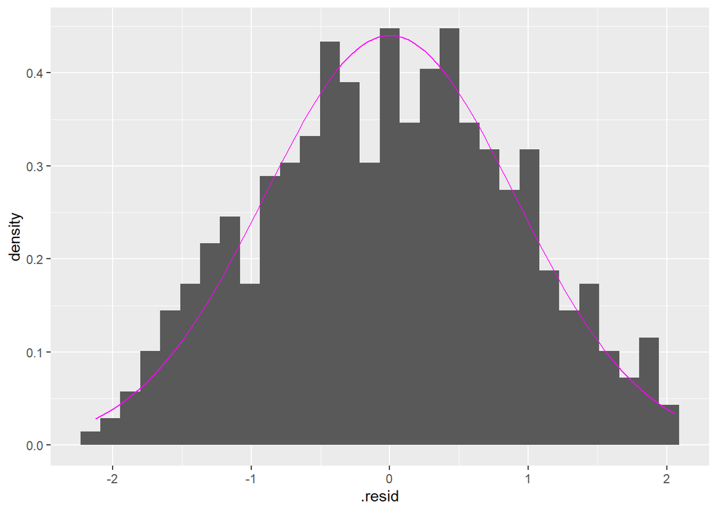

```r
ggplot(data = Pred.FinalModelNoInfluence, aes(x=.resid)) +
  geom_histogram(aes(y=..density..)) +
  stat_function(fun = dnorm, colour = "magenta",
                args = list(mean = mean(Pred.FinalModelNoInfluence$.resid),
                            sd = sd(Pred.FinalModelNoInfluence$.resid)))
```

Residual Histogram look normally distributed

Scatter plot between Predicted and Residual value

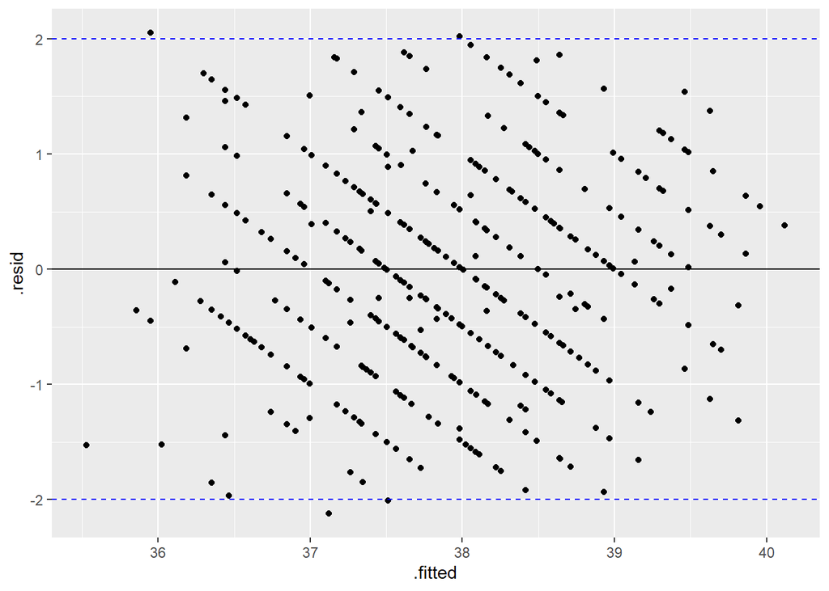

```r
ggplot(data = Pred.FinalModelNoInfluence, aes(x=.fitted, y=.resid)) +
  geom_point() +
  geom_hline (yintercept = 0) +
  geom_hline (yintercept = 2, linetype=2, color="blue") +
  geom_hline (yintercept = -2, linetype=2, color="blue")
```

Scatter plot seem linear and constant

Thus, these two assumption for linear regression is fulfilled

1. for each set of $X$<sub>i</sub> values, there is a sub-population of $Y$ values which are normally distributed.
2. the variance of the sub-population of $Y$ are all equal

Qualitatively, diagnostic plot for Final Model without Influence look *leaner*. Otherwise adjusted R<sup>2</sup> for Final Model without Influence was higher.

Thus the final model will based on new model without influence samples.

# Final Model & Interpretation

## Final Model

Model

$Y = \beta_0 + \beta_1X_1 + \beta_2X_2 + \beta_3X_3$

- $X_1$ - length
- $X_2$ - gender
- $X_3$ - parity

```r
summary(FinalModelNoInfluential)
```

```
##
## Call:
## lm(formula = ModelPrelim, data = NonInfluenObs)
##
## Residuals:
##      Min       1Q   Median       3Q      Max
## -2.12254 -0.64978  0.03099  0.64903  2.05179
##
## Coefficients:
##                          Estimate Std. Error t value Pr(>|t|)
## (Intercept)              19.95790    1.06077  18.815  < 2e-16 ***
## length                    0.32905    0.01916  17.171  < 2e-16 ***
## genderFemale             -0.55294    0.08704  -6.353 4.95e-10 ***
## parityOne sibling         0.25534    0.09680   2.638  0.00862 **
## parity2 siblings          0.44252    0.11273   3.926 9.93e-05 ***
## parity3 or more siblings  0.26013    0.21813   1.193  0.23364
## ---
## Signif. codes:  0 '***' 0.001 '**' 0.01 '*' 0.05 '.' 0.1 ' ' 1
##
## Residual standard error: 0.9109 on 475 degrees of freedom
## Multiple R-squared:  0.4833, Adjusted R-squared:  0.4779
## F-statistic: 88.87 on 5 and 475 DF,  p-value: < 2.2e-16
```

```r
kable(tidy(FinalModelNoInfluential, conf.int = T))
```

| term | estimate | std.error | statistic | p.value | conf.low | conf.high |
| --- | --- | --- | --- | --- | --- | --- |
| (Intercept) | 19.9579008 | 1.0607695 | 18.814550 | 0.0000000 | 17.8735197 | 22.0422819 |
| length | 0.3290487 | 0.0191630 | 17.171016 | 0.0000000 | 0.2913939 | 0.3667035 |
| genderFemale | -0.5529428 | 0.0870370 | -6.352961 | 0.0000000 | -0.7239680 | -0.3819176 |
| parityOne sibling | 0.2553355 | 0.0968039 | 2.637656 | 0.0086219 | 0.0651186 | 0.4455525 |
| parity2 siblings | 0.4425243 | 0.1127273 | 3.925617 | 0.0000993 | 0.2210184 | 0.6640302 |
| parity3 or more siblings | 0.2601264 | 0.2181259 | 1.192551 | 0.2336404 | -0.1684847 | 0.6887375 |

head circumference = 19.96 + 0.33(length) - 0.55(female = 1) + 0.26(One sibling = 1) + 0.44(2 siblings = 1) + 0.26(3 or more siblings = 1)

## Model Interpretation

The relationship can be explained as below

Model assumptions were met. There were no interaction nor multicollinearity between independent variables.

Low coefficient of determination, R<sup>2</sup> is most likely due to underfitting. There might be unexplained variation, which can be exlained by other variables outside of the scope of this study. But for this research purpose, with available variables, the model stated above is the best model available.

# Prediction

## Prediction with New Dataset

### Create New Dataset

new data was created using these parameter

- length - 45cm, mean newborn’s length, 65cm
- gender - both male and female
- parity - singleton, one sibling, 2 siblings and 3 or more siblings

```r
DS_cons <- expand.grid(length = c(45, mean(NonInfluenObs$length), 65),
                        gender = c('Male', 'Female'),
                        parity = c('Singleton', 'One sibling','2 siblings', '3 or more siblings'))
kable(head(DS_cons))
```

| length | gender | parity |
| --- | --- | --- |
| 45.00000 | Male | Singleton |
| 54.73306 | Male | Singleton |
| 65.00000 | Male | Singleton |
| 45.00000 | Female | Singleton |
| 54.73306 | Female | Singleton |
| 65.00000 | Female | Singleton |

```r
kable(tail(DS_cons))
```

|  | length | gender | parity |
| --- | --- | --- | --- |
| 19 | 45.00000 | Male | 3 or more siblings |
| 20 | 54.73306 | Male | 3 or more siblings |
| 21 | 65.00000 | Male | 3 or more siblings |
| 22 | 45.00000 | Female | 3 or more siblings |
| 23 | 54.73306 | Female | 3 or more siblings |
| 24 | 65.00000 | Female | 3 or more siblings |

### Calculate Predicted Values with New Dataset

```r
DataSetPred.NewDS <- augment(FinalModelNoInfluential, newdata = DS_cons)
kable(head(DataSetPred.NewDS))
```

| length | gender | parity | .fitted |
| --- | --- | --- | --- |
| 45.00000 | Male | Singleton | 34.76509 |
| 54.73306 | Male | Singleton | 37.96774 |
| 65.00000 | Male | Singleton | 41.34607 |
| 45.00000 | Female | Singleton | 34.21215 |
| 54.73306 | Female | Singleton | 37.41480 |
| 65.00000 | Female | Singleton | 40.79313 |

```r
kable(tail(DataSetPred.NewDS))
```

| length | gender | parity | .fitted |
| --- | --- | --- | --- |
| 45.00000 | Male | 3 or more siblings | 35.02522 |
| 54.73306 | Male | 3 or more siblings | 38.22787 |
| 65.00000 | Male | 3 or more siblings | 41.60620 |
| 45.00000 | Female | 3 or more siblings | 34.47228 |
| 54.73306 | Female | 3 or more siblings | 37.67493 |
| 65.00000 | Female | 3 or more siblings | 41.05325 |